# MA304: Data Visualisation Final Project

Faryal Zaidi - 2211398

# Abstract:

The aim of this project was to undertake a thorough data visualisation on the policing dataset from Dallas, Texas in 2016, with the goal of identifying any hidden patterns or trends that may have been present in the data. We examined crime frequency, places with the greatest crime rates, and crime kinds using appropriate visualisation approaches. Our investigation showed several intriguing findings, including the concentration of crimes in certain places, the incidence of certain sorts of crimes, and the time of day most crimes occurred. These findings can help law enforcement and lawmakers build crime-fighting and public safety measures.

# Introduction:

The goal of this project is to create a comprehensive data visualisation of the 2016 police data set from Dallas, Texas. The dataset includes information about incidents that occurred in Dallas, Texas in 2016, including the incident category, location, date and time, and the individuals involved.

The objective of this task is to investigate and analyse the dataset using visualisations and to provide insight into the relationships, trends, and patterns within the data. This analysis may help law enforcement bodies, policymakers, and the general public better comprehend the characteristics of police work incidents in Dallas as well as make well-informed decisions based on the data-driven insights gained.

A wide variety of data visualisation methods, including tables, histograms, bar charts, pie charts, dot plots, density plots, scatter plots, box plots, correlation analysis, time series plot and map or leaflet, can be applied to this endeavour. Making effective data visualisations that communicate the most important takeaways will be a top priority.

**Read Policing Dataset**

After importing data into R, you can perform a wide range of analyses on the information. Before proceeding with data visualisation or statistical analysis, it is essential to clean and preprocess the data.

```r
pdata <- read.csv('37-00049_UOF-P_2016_prepped.csv')
pdata <- slice(pdata, 2:nrow(pdata))  #eliminating first row as it was heading
```

# Two-way Table for Officer and Subject Gender

We will use police data, which is Dallas, Texas data relating to the year 2016, having real-time fields and information relating to locations, officers, divisions, and the subjects of crimes reported. We will be exploring the data for analysis to make frequent patterns visible and extract valuable knowledge for future decisions.

A table, or two-way table, is a type of R data visualisation used to summarise and display tabular data. It’s a straightforward method of showing how many times each value appears in a dataset. Here, the two-way table provides information regarding the number of officers and subjects who correspond to each gender combination. The rows show the gender of the officer (male or female), and the columns represent the gender of the subject (male, female, null, or unknown).

```r
#Two way table also called contingency table
table(pdata$OFFICER_GENDER, pdata$SUBJECT_GENDER)
```

```
##
##          Female Male NULL Unknown
##   Female     77  160    2       1
##   Male      363 1772    8       0
```

# Table for Racial and Gender Disparities

In the context of conducting an investigation of racial and gender inequalities, the identification of patterns can be of use in determining whether or not particular groups are disproportionately impacted by particular outcomes or behaviours. These information may be an indication that there are deeper systemic problems that need to be addressed in order to make sure that policing is fair and just for all people, regardless of their race or gender.

```r
summary_race_gender  <- pdata %>%
    filter(!is.na(OFFICER_RACE), !is.na(OFFICER_GENDER), !is.na(SUBJECT_RACE), !is.na(SUBJECT_GENDER)) %>%
    group_by(OFFICER_RACE, OFFICER_GENDER, SUBJECT_RACE, SUBJECT_GENDER) %>%
    summarize(n = n()) %>%
    ungroup()
 head(summary_race_gender)
```

```
## # A tibble: 6 × 5
##   OFFICER_RACE OFFICER_GENDER SUBJECT_RACE SUBJECT_GENDER     n
##   <chr>        <chr>          <chr>        <chr>          <int>
## 1 American Ind Female         Black        Female             1
## 2 American Ind Female         Black        Male               1
## 3 American Ind Male           Black        Male               5
## 4 American Ind Male           White        Male               1
## 5 Asian        Female         Black        Female             1
## 6 Asian        Female         Black        Male               3
```

```r
 summary_race_gender$n <- factor(summary_race_gender$n)
(max_row <- summary_race_gender[which.max(summary_race_gender$n),])
```

```
## # A tibble: 1 × 5
##   OFFICER_RACE OFFICER_GENDER SUBJECT_RACE SUBJECT_GENDER n
##   <chr>        <chr>          <chr>        <chr>          <fct>
## 1 White        Male           Black        Male           627
```

# Cases of repeated and non-repeated arrests

In the case of indicating repeated and non-repeated arrests in the crime data, a histogram can assist us in gaining a better understanding of the frequency and distribution of arrests for each individual subject. The data is categorised according to the officer and the subject id, a count of the number of occurrences is performed, and this count is combined with the count of distinct subjects for each officer. In the final step, it determines the frequency of repeated arrests for each officer and then generates a histogram to display the distribution of those frequencies. We are able to determine whether subjects are repeat offenders by further categorising the data by SUBJECT_ID and tallying the number of times each subject has been arrested by different police.

**Histogram for Frequency of repeat arrests:**

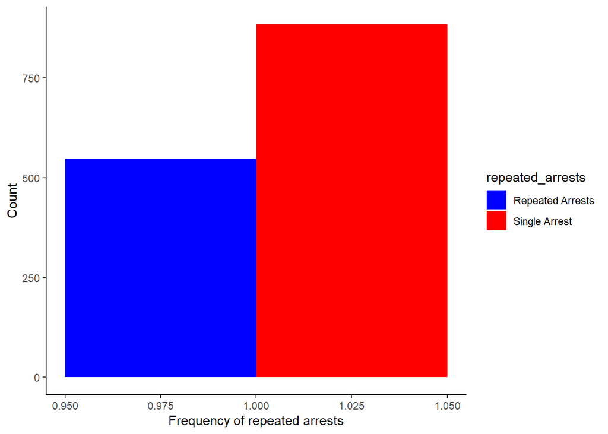

This information can be utilised to prioritise the efforts of law enforcement and direct resources towards the reduction of crime committed by repeat offenders. Examining the bars and the heights they represent is necessary for an accurate interpretation of the histogram. The x-axis indicates the frequency of subjects, while the y-axis depicts the count of arrests that have been made. The arrests that did not occur more than once are depicted by the bars on the right side of the histogram in Red color, while those that occurred more than once are shown by the bars on the left side in blue color. It is clear to see that the height of the bars indicating arrests for the first time only is significantly greater than the height of the bars indicating arrests for the second time or more. This indicates that there are a significantly larger number of individuals who have only been arrested a single time as opposed to those who have been arrested more than once.

# Dot Plot of Subject Descriptions per Incident

**Dot Plot for Subject Description per incident:**

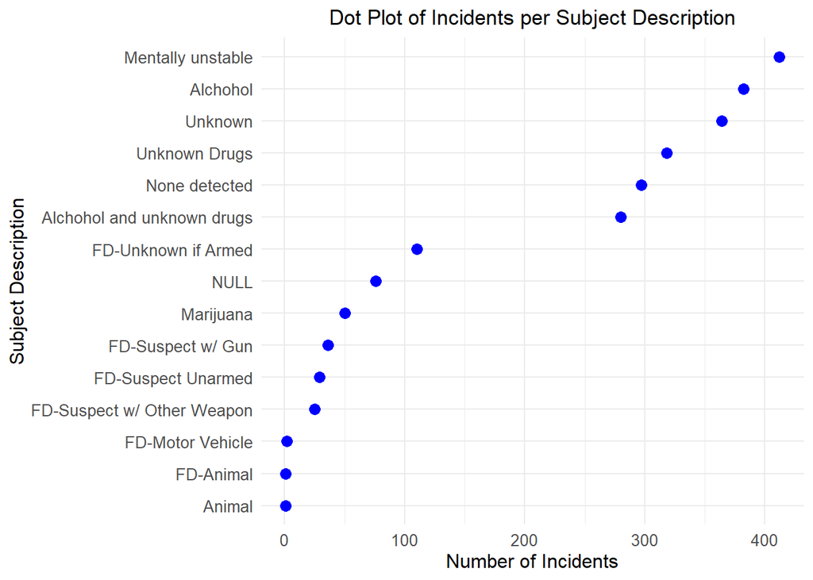

# Pie Chart to Visualize Incident Reason Causes in Police Data

We create a pie chart illustrating the distribution of incident reason causes in police data.The polar pie chart is excellent for visualising incident reasons, which can aid analysis and decision-making. We decided to make a polar pie chart so that we could better understand how the various event reason causes were distributed throughout the data collected by the police. As the data is shown in the form of slices of a circle, this particular sort of chart is the most effective one for displaying the relative proportions of various categories. The size of each slice of the pie corresponds to the percentage of total occurrences that fall into that category. The pie is divided into categories of incident reason causes, and each slice of the pie reflects one of these categories.

**Pie Chart for Reason per incident:**

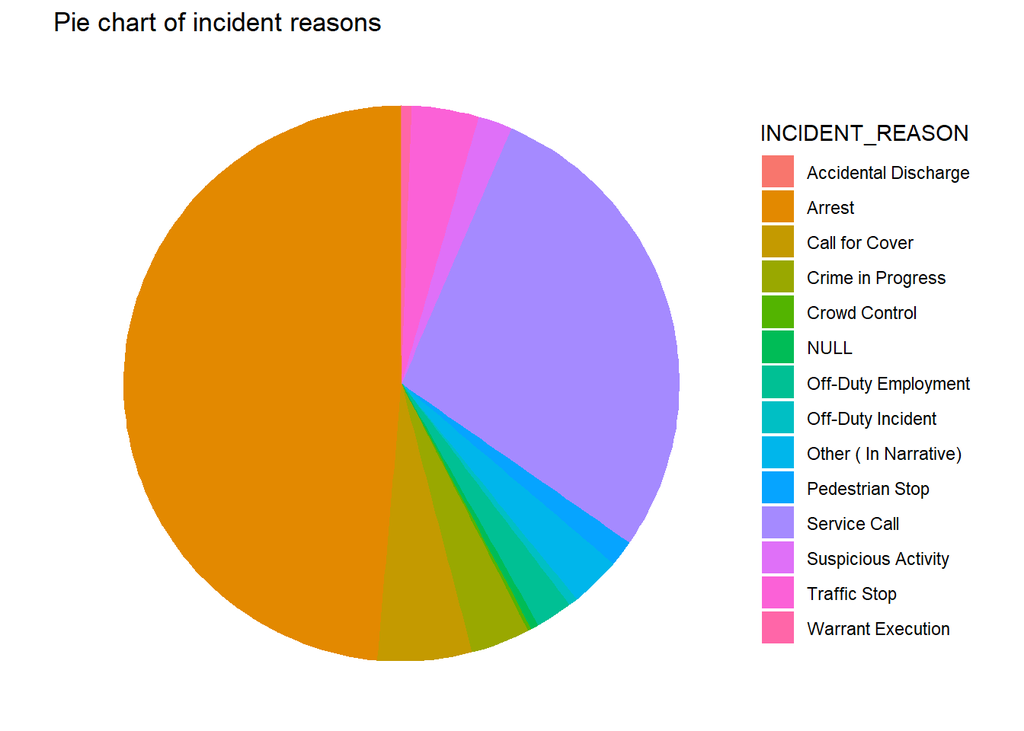

```r
# ==================PIE CHART =============================================
# Pie chart
ggplot(pdata, aes(x = "", fill = INCIDENT_REASON)) +
  geom_bar(width = 1) +
  coord_polar("y", start=0) +
  ggtitle("Pie chart of incident reasons") +
  theme_void()
```

Interpreting this figure helps determine the dataset’s incident reasons. The angle of each segment in the polar pie chart denotes the percentage of incidences ascribed to that reason. The graphic shows a huge **Arrest** segment, suggesting arrest was the main cause of police incidents in the dataset. **Service Call** followed. All other reasons in the chart have a small segment, suggesting that the data is not as prevalent.

# Comparing Divisional Incident Rates by Bar Plot

Bar plots are useful for visualising categorical data like police division incident occurrences. A bar plot can reveal data trends that may not be obvious from the raw figures. The bar plot that displays the frequency of occurrences across different divisions is an important component in the study of crime data. Not only does it assist in locating the regions that have high crime rates, but it also offers insights into the overall pattern of crimes across the various divisions. This knowledge can be put to use in a way that is both more effective and more efficient in the process of allocating resources and planning strategies for crime prevention. In the event that one division persistently reports a larger number of events, for instance, law enforcement authorities may decide to allot extra resources to that division in order to address the issue.

**Bar Plot for extracting the frequencies of incident per Division**

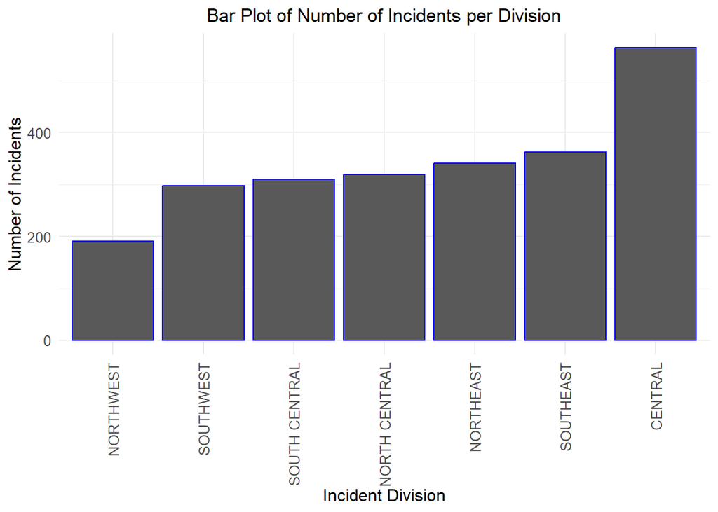

These data imply that the Central division is the most crime-prone, however, law enforcement may need to focus on select locations in the Central, Southeast, and Northeast divisions to reduce crime. Southwest and Northwest divisions had fewer incidences than North Central and South Central divisions. These findings can assist police agencies in detecting criminal patterns and allocate resources and methods to better combat crime in their communities. However, due to data constraints and possible confounding factors, these results should be interpreted carefully.

# Analysis of Crime Incident’s Date and Time by Density Plot

The density plot depicts incident distribution by month and hour in a continuous manner. It suggests patterns and trends that may help police operations. Below plot displays the distribution of incidents by the hour and by the month. It gives a sense of when incidents are most probable to occur, which can be helpful in spotting patterns and trends in crime data.

**Density Plot of Incident’s month and hour:**

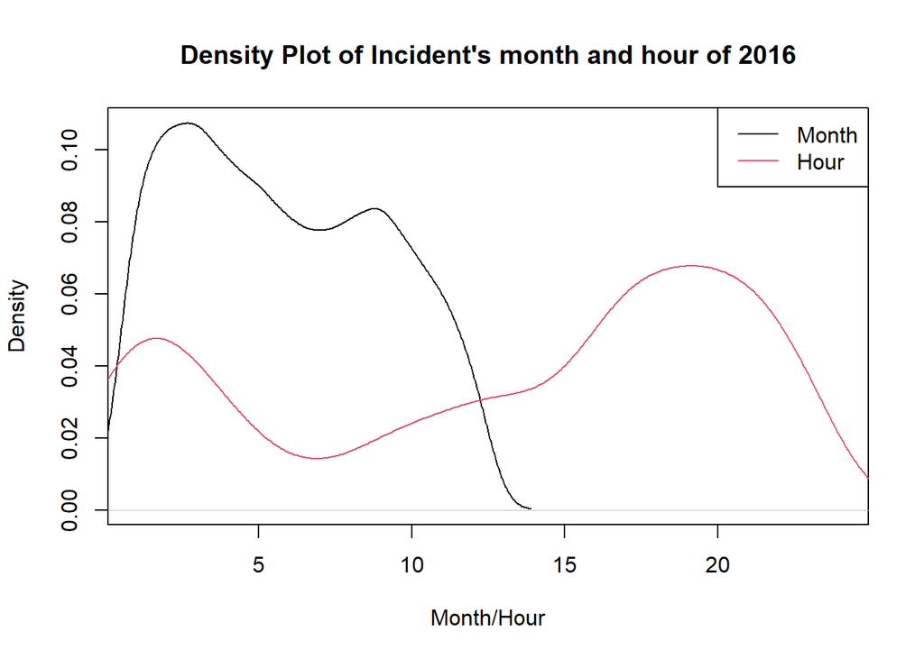

The findings also show that peak-hour police response may require extra resources. Hire more cops or use technology to reduce incident response times. The density plot of incident occurrences by month and hour can help police departments design successful prevention and response tactics. Police departments can allocate resources and prioritise public safety by recognising data patterns and trends.

# Observing Police Data by Box Plot/Violin Plot

For a rapid overview of the data, including the minimum and maximum values, median, and outliers, a box plot can be used to depict the distribution of officers’ years on force. It can be used to infer police officers’ average years on the job. Inexperienced cops or those nearing retirement might be easily spotted in this way. This data could be used to assess the efficacy of training programmes or locate openings for officers with more seniority. This data could also reveal any bias in hiring or promoting police officers depending on their level of experience.

**Box Plot for Officer’s Years on Force:**

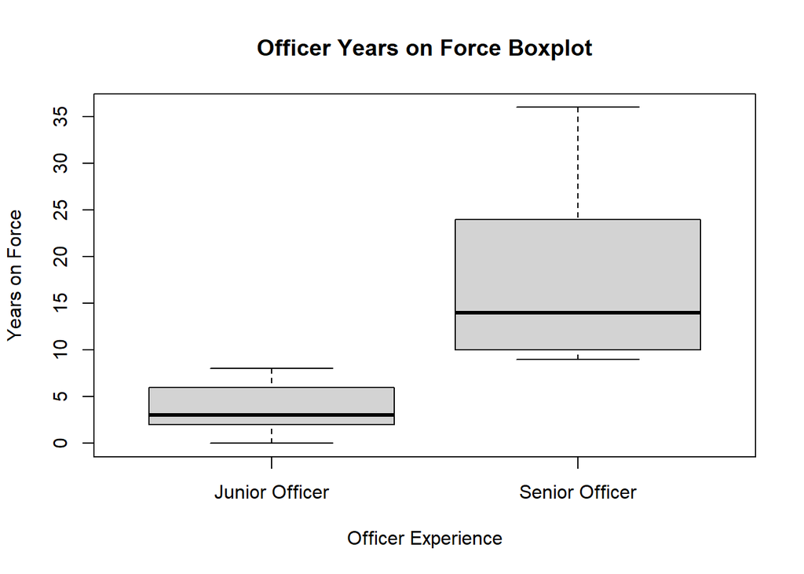

**Violin Plot of Location district against months of 2016:**

The violin plot for location district and months in police data illustrates incident occurrences across districts and months continuously. The x-axis represents location district and the y-axis months.

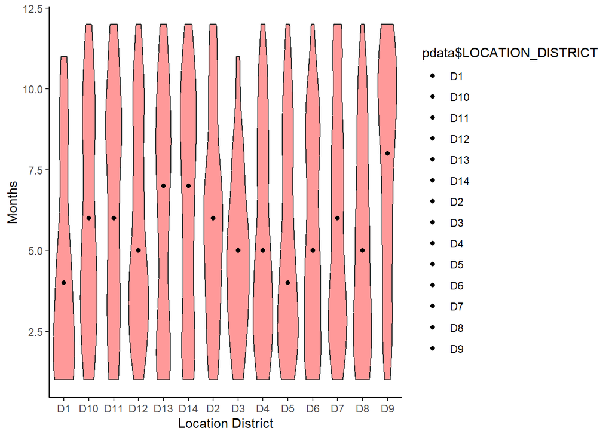

```r
# ============================VIOLIN PLOT for OFFICER_YEARS_ON_FORCE====================
ggplot(pdata, aes(x=factor(pdata$LOCATION_DISTRICT),  y=pdata$month, fill=pdata$LOCATION_DISTRICT)) + xlab("Location District") + ylab("Months") +
  geom_violin(fill="red", alpha=0.4) +
  stat_summary(fun.y = median, geom='point')
```

This plot reveals incident dispersion across months and districts. The graphic shows which districts had more incidents in different months. Fisrt 6 months are more crime prone in D1, D12, D3, D4, D5. The plot’s wide distribution indicates considerable incidence rate variability across districts and months. This suggests that police departments may need to address particular reasons or occurrences to minimise incident rates. However, a narrow distribution indicates a constant occurrence rate across districts and months. The violin plot for geographic district and months in police data is a strong tool for identifying incident rate patterns and trends. It can help police and policymakers prevent, respond to, and improve public safety.

# Relationship between subject injuries and location of arrest

**Scatter Plot of Location of subjects were injured arrested:**

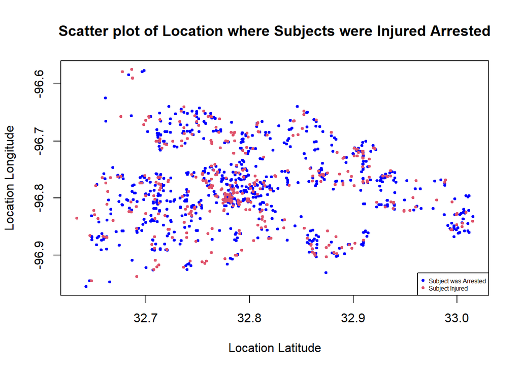

**Analysing the Reason of Force used by Officers:**

In the context of the research on police-civilian interactions, one essential component is the investigation of the rationale for the use of force by officers. We can find out the reason for force used by the officers in a crime incident. To better understand the circumstances that led to the use of force and the reasons that influenced the decision-making of the officers, it is helpful to gain an understanding of those conditions.

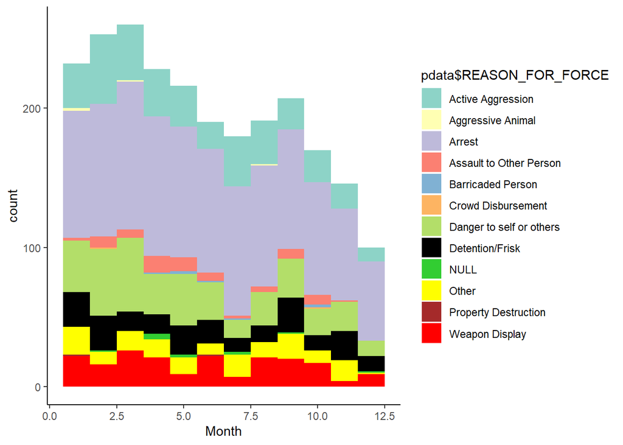

```r
clr <- c('#8dd3c7','#ffffb3','#bebada','#fb8072','#80b1d3','#fdb462','#b3de69', '#000000', 'limegreen','yellow','brown', 'red')
ggplot(pdata, aes(x=pdata$month, fill=pdata$REASON_FOR_FORCE)) +
  geom_histogram(binwidth=1) +
  scale_fill_manual(values = clr) +
  xlab("Month")
```

According to this study’s findings, the circumstances under which law enforcement officials resort to the use of physical force can be broken down into a number of distinct types. It is evident from the preceding graph that Arrest, Active Aggression, Danger to Oneself or Others, and Weapon Display were the most common reasons for officers to use force. Accountability and transparency in law enforcement depend on understanding why an officer used force during a criminal incident. Understanding why police officers use force can enhance their training for similar situations. Transparency and accountability surrounding incidents involving the use of force can enhance law enforcement-community relations and public confidence in law enforcement.

# Exploring Correlations Among Incident Characteristics: Month, Hour, Reason, Division, and Subject Description

The correlation analysis offers helpful insights into the correlations between the variables in the data set, which may be used to assist in the process of recognising patterns and developing predictions. In this particular scenario, we are able to conduct a correlation analysis between the month, hour, reason, division, and subject description of the incident in order to comprehend how these elements are connected to one another.

**Correlation analysis between Incident’s month, hour, reason, division and subject description:**

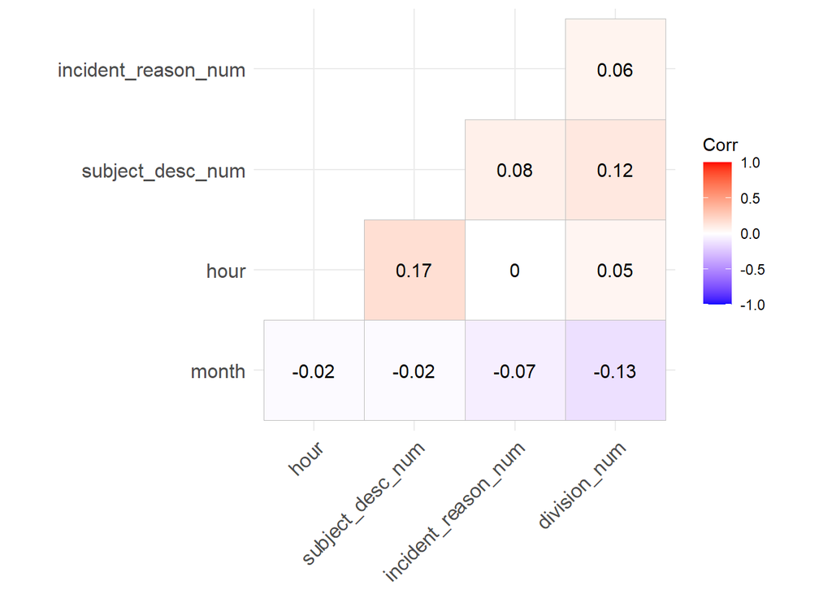

The correlation matrix illustrates the pairwise correlation between the variables “month”, “hour”, “incident_reason_num”, “subject_desc_num”, and “division_num”. The character columns are converted to integers for their factors, and then they are converted to numeric values for correlation analysis. Positive values indicate a positive correlation, while negative values indicate a negative correlation, and values near to zero indicate that there is no correlation.

Overall, correlation analysis can assist us in understanding how various variables are related to one another and can be used to recognise patterns and trends in data pertaining to crime.

# Time Series Analysis on Date Column: Exploring Trends and Patterns in the Data

Time series analysis is a statistical method that can be used to investigate and model data that is reliant on the passage of time. Analysing the patterns, trends, and behaviour of a time series dataset over the course of a predetermined amount of time is entailed in this process.

**Time Series Plot of Incident Date and Officer Hire Date:**

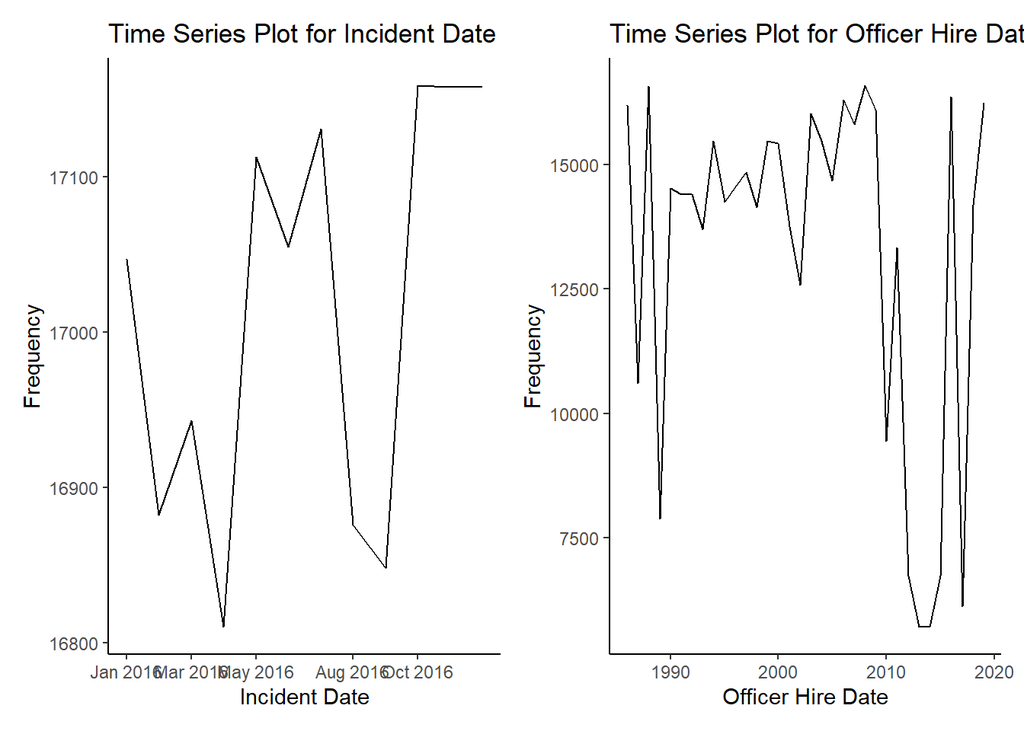

**The use of smoothing to illustrate pattern/trend:**

Smoothing is a method that may be used to time series data in order to reduce the amount of noise present in the data by averaging out the fluctuations and drawing attention to the underlying patterns and trends. In addition to making it simpler to visualise and understand the data, it also assists in determining the long-term behaviour of the time series being examined.

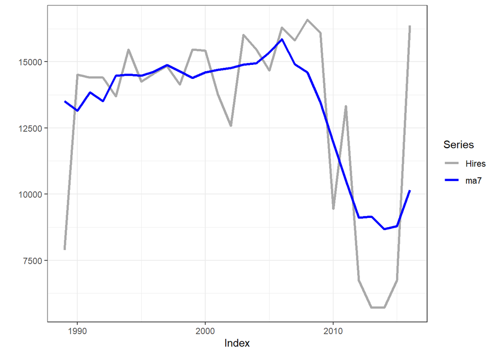

We will examine the time series plot for the officer hiring date. Our goal is to discover the patterns in the hiring of officers over the course of the previous 37 years, and we will decide in which year over the course of the previous three decades the hiring was at its highest point. This information will provide us with insightful patterns about the recruitment of officers.

# Exploring Crime Hotspots with an Interactive Leaflet Map: Crime Types Across Locations

When it comes to analysing and visually representing crime data, a valuable tool at your disposal is the mapping and interactive mapping capabilities offered by the Leaflet package in R. The mapping of crime data helps to discover patterns and trends in criminal activity, gain a better understanding of crime hotspots, and improve law enforcement organisations’ ability to allocate resources.

**Horizontal bar plot for Crime Type:**

Firstly to identify the types of crime reported in our dataset we represent the horizontal bar plot.

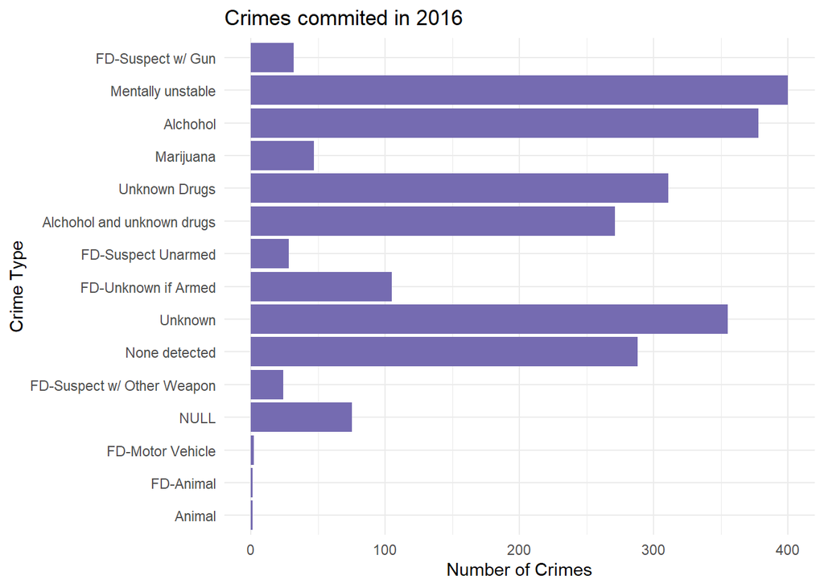

**Interactive Map for Crime type:**

The usage of point maps, in which each individual criminal act is depicted as a point on the map, is a frequent method for mapping data pertaining to criminal activity. The colour of the point may be utilised to signify the category or type of criminal activity that took place as well as other pertinent information.

[interactive chart not shown]

It is common practise in the study of crime data to make use of interactive maps in order to visualise and investigate patterns and trends in the occurrence of crime across geographic regions. Crime occurrences can be displayed on the maps as points or clusters, and they can be color-coded to identify the category of crime. In our case, we have displayed different subject descriptions with unique colors on the map.The code is making use of the Leaflet package that is available in R to generate an interactive map that shows the locations of various forms of criminal activity. It adds circle markers to the map for each category of crime based on the latitude and longitude coordinates in the crime data. These coordinates can be found in the crime data. The category of criminal activity determines both the colour of the circle markers and the group to which they belong.

Within the map, various subjects have been given their own unique colours according to the category that best describes them. The following is an example of the color coding that is used:

“mentally unstable”: **Red**

“Alcohol”: **Blue**

“Unknown Drugs”: **Green**

“Marijuana”: **Brown**

“FD-Unknown if Armed”: **Orange**

“FD-Suspect with Gun”: **Purple**

These colours have been utilised so that the various subject categories may be distinguished from one another on the map, hence making it simpler to locate clusters of incidents associated with each subject category. The finished map makes it possible to get a clear picture of where the various categories of criminal activity are concentrated within the area.

# Conclusion:

This project report’s objective was to carry out a comprehensive study of the dataset pertaining to police in order to identify any latent patterns or tendencies by utilising the most appropriate visualisation approaches. We were able to get insights into numerous areas of policing as a result of the analysis, such as the frequency of various sorts of criminal activity, the demographic distribution of people involved in incidents, the places where incidents happened, and the types of weapons that were utilised. This information can be helpful to law enforcement agencies in identifying potential places of improvement that could be made in their operations. Some examples of such areas include expanding patrols in regions where incidents occur more frequently or boosting officer training in how to respond to specific sorts of incidents. The report also emphasises the significance of data analysis in police and the possible benefits that can be realised through adopting information-driven decision-making processes to enhance general public safety. These potential benefits include an improvement in overall public safety.

After working with the data, we have discovered several patterns and trends that were not evident to the naked eye. By applying approaches from the field of data science visualisation, we have been able to reveal information that will be helpful in the future decision-making of law enforcement authorities.